# Growth Mixture Model Simulation Study

Laurens Bogaardt

2023-06-12

# Introduction

Relevant references include:

- Herle, M., Micali, N., Abdulkadir, M. et al. Identifying typical trajectories in longitudinal data: modelling strategies and interpretations. Eur J Epidemiol 35, 205–222 (2020). https://doi.org/10.1007/s10654-020-00615-6
- Audrain-McGovern J, Rodriguez D, Tercyak KP, Cuevas J, Rodgers K, Patterson F. Identifying and characterizing adolescent smoking trajectories. Cancer Epidemiol Biomarkers Prev. 2004 Dec;13(12):2023-34. PMID: 15598757.
- Donovan JE, Chung T. Progressive elaboration and cross-validation of a latent class typology of adolescent alcohol involvement in a national sample. J Stud Alcohol Drugs. 2015 May;76(3):419-29. doi: 10.15288/jsad.2015.76.419. PMID: 25978828; PMCID: PMC4440300.
- Jung, T., & Wickrama, K. A. S. (2008). An introduction to latent class growth analysis and growth mixture modeling. Social and Personality Psychology Compass, 2(1), 302–317. https://doi.org/10.1111/j.1751-9004.2007.00054.x
- Gilthorpe MS, Dahly DL, Tu YK, Kubzansky LD, Goodman E. Challenges in modelling the random structure correctly in growth mixture models and the impact this has on model mixtures. J Dev Orig Health Dis. 2014 Jun;5(3):197-205. doi: 10.1017/S2040174414000130. PMID: 24901659; PMCID: PMC4098080.
- McNeish D, Peña A, Vander Wyst KB, Ayers SL, Olson ML, Shaibi GQ. Facilitating Growth Mixture Model Convergence in Preventive Interventions. Prev Sci. 2023 Apr;24(3):505-516. doi: 10.1007/s11121-021-01262-3. Epub 2021 Jul 7. PMID: 34235633; PMCID: PMC9004621.
- Hipp JR, Bauer DJ. Local solutions in the estimation of growth mixture models. Psychol Methods. 2006 Mar;11(1):36-53. doi: 10.1037/1082-989X.11.1.36. PMID: 16594766.

The document uses the package *tidyverse* and *lcmm*. And we set a seed to ensure each run of this document produces the same output.

```r
library(tidyverse)
library(lcmm)
set.seed(123)
```

# Functions

```r
generate.and.estimate.growth.mixture.models <- function(n.participants, n.measurements, class.intercept, fixed.intercept.1, fixed.intercept.2, sd.random.intercept, sd.error) {
  class.y <- class.intercept + rlogis(n.participants)
  class <- as.numeric(class.y < 0)
  participant.intercept <- fixed.intercept.1 + class * (fixed.intercept.2 - fixed.intercept.1) + sd.random.intercept * rnorm(n.participants)
  y <- rep(participant.intercept, each = n.measurements) + sd.error * rnorm(n.participants * n.measurements)
  participant.id <- rep(seq(n.participants), each = n.measurements)
  model.1 <- hlme(
    fixed = y ~ 1,
    random = ~ 1,
    subject = "participant.id",
    ng = 1,
    data = data.frame(
      y = y,
      participant.id = participant.id
    )
  )
  model_2 <- gridsearch(
    m = hlme(
      fixed = y ~ 1,
      mixture = ~ 1,
      random = ~ 1,
      subject = "participant.id",
      classmb = ~ 1,
      ng = 2,
      data = data.frame(
        y = y,
        participant.id = participant.id
      )
    ),
    rep = 10,
    maxiter = 10,
    minit = model.1
  )
  model <- hlme(
    fixed = y ~ 1,
    mixture = ~ 1,
    random = ~ 1,
    subject = "participant.id",
    classmb = ~ 1,
    ng = 2,
    B = c(class.intercept, fixed.intercept.1, fixed.intercept.2, sd.random.intercept, sd.error),
    data = data.frame(
      y = y,
      participant.id = participant.id
    )
  )
  result <- data.frame(
    class.intercept = coef(model)[[1]],
    fixed.intercept.1 = coef(model)[[2]],
    fixed.intercept.2 = coef(model)[[3]],
    sd.random.intercept = abs(coef(model)[[4]]),
    sd.error = abs(coef(model)[[5]]),
    class.intercept_2 = coef(model_2)[[1]],
    fixed.intercept.1_2 = coef(model_2)[[2]],
    fixed.intercept.2_2 = coef(model_2)[[3]],
    sd.random.intercept_2 = abs(coef(model_2)[[4]]),
    sd.error_2 = abs(coef(model_2)[[5]])
  )
  return(result)
}
```

# Parameters

```r
parameters <- tibble(
  parameter.set = seq(8),
  n.participants = c(200, 800, 200, 200, 200, 200, 200, 200),
  n.measurements = c(5, 5, 10, 5, 5, 5, 5, 5),
  class.intercept = c(1, 1, 1, 0.5, 1, 1, 1, 1),
  fixed.intercept.1 = c(-3, -3, -3, -3, -2.5, -3, -3, -3),
  fixed.intercept.2 = c(0.5, 0.5, 0.5, 0.5, 0.5, 0.9, 0.5, 0.5),
  sd.random.intercept = c(0.3, 0.3, 0.3, 0.3, 0.3, 0.3, 0.6, 0.3),
  sd.error = c(0.4, 0.4, 0.4, 0.4, 0.4, 0.4, 0.4, 0.5)
)
parameters
```

| parameter.set | n.participants | n.measurements | class.intercept | fixed.intercept.1 | fixed.intercept.2 | sd.random.intercept | sd.error |
| --- | --- | --- | --- | --- | --- | --- | --- |
| 1 | 200 | 5 | 1.0 | -3.0 | 0.5 | 0.3 | 0.4 |
| 2 | 800 | 5 | 1.0 | -3.0 | 0.5 | 0.3 | 0.4 |
| 3 | 200 | 10 | 1.0 | -3.0 | 0.5 | 0.3 | 0.4 |
| 4 | 200 | 5 | 0.5 | -3.0 | 0.5 | 0.3 | 0.4 |
| 5 | 200 | 5 | 1.0 | -2.5 | 0.5 | 0.3 | 0.4 |
| 6 | 200 | 5 | 1.0 | -3.0 | 0.9 | 0.3 | 0.4 |
| 7 | 200 | 5 | 1.0 | -3.0 | 0.5 | 0.6 | 0.4 |
| 8 | 200 | 5 | 1.0 | -3.0 | 0.5 | 0.3 | 0.5 |

# Estimation

```r
estimated.parameters <- parameters %>%
  expand_grid(
    run = seq(10)
  ) %>%
  rowwise() %>%
  mutate(
    generate.and.estimate.growth.mixture.models(
      n.participants = n.participants,
      n.measurements = n.measurements,
      class.intercept = class.intercept,
      fixed.intercept.1 = fixed.intercept.1,
      fixed.intercept.2 = fixed.intercept.2,
      sd.random.intercept = sd.random.intercept,
      sd.error = sd.error
    )
  ) %>%
  ungroup()
```

```
## Infinite parameters...
## Last step values :
##       b : 6.472e-05 -1.510813 -1.515687 1.764801 -0.3945973
##       objective function : -950.5734
##       Convergence criteria: parameters stability= 0
##                           : function stability= 0
##                           : best relative distance to maximum obtained (RDM)= 0.375149
```

```r
estimated.parameters
```

| parameter.set | n.participants | n.measurements | class.intercept | fixed.intercept.1 | fixed.intercept.2 | sd.random.intercept | sd.error | run | class.intercept_2 | fixed.intercept.1_2 | fixed.intercept.2_2 | sd.random.intercept_2 | sd.error_2 |
| --- | --- | --- | --- | --- | --- | --- | --- | --- | --- | --- | --- | --- | --- |
| 1 | 200 | 5 | 1.09861173 | -2.988358 | 0.4978126 | 0.3125151 | 0.4016353 | 1 | -1.09861229 | 0.4978126 | -2.9883576 | 0.3125151 | 0.4016353 |
| 1 | 200 | 5 | 1.20831088 | -2.990724 | 0.6089238 | 0.2523212 | 0.4031034 | 2 | -1.20831120 | 0.6089238 | -2.9907241 | 0.2523212 | 0.4031034 |
| 1 | 200 | 5 | 1.15267950 | -2.981256 | 0.5226171 | 0.3048596 | 0.3983475 | 3 | 1.15267951 | -2.9812563 | 0.5226170 | 0.3048597 | 0.3983475 |
| 1 | 200 | 5 | 0.84729867 | -3.022462 | 0.5280496 | 0.2756313 | 0.3958092 | 4 | 0.84729658 | -3.0224617 | 0.5280496 | 0.2756313 | 0.3958092 |
| 1 | 200 | 5 | 1.02014067 | -2.996179 | 0.5217036 | 0.2812222 | 0.4042777 | 5 | 1.02014067 | -2.9961790 | 0.5217037 | 0.2812222 | 0.4042777 |
| 1 | 200 | 5 | 0.73088751 | -3.003441 | 0.4841112 | 0.2708607 | 0.4048897 | 6 | 0.73088751 | -3.0034413 | 0.4841112 | 0.2708607 | 0.4048897 |
| 1 | 200 | 5 | 0.73088752 | -2.975840 | 0.5582587 | 0.2999380 | 0.4089485 | 7 | 0.73088750 | -2.9758405 | 0.5582586 | 0.2999380 | 0.4089485 |
| 1 | 200 | 5 | 1.35533214 | -3.020061 | 0.5405579 | 0.2959838 | 0.3909004 | 8 | -1.35533214 | 0.5405579 | -3.0200606 | 0.2959838 | 0.3909004 |
| 1 | 200 | 5 | 0.91979336 | -3.011423 | 0.5361406 | 0.2787641 | 0.3988824 | 9 | 0.91979334 | -3.0114227 | 0.5361408 | 0.2787640 | 0.3988824 |
| 1 | 200 | 5 | 0.99462258 | -2.994698 | 0.4502433 | 0.3107800 | 0.3905638 | 10 | 0.99462325 | -2.9946978 | 0.4502432 | 0.3107801 | 0.3905638 |

[output cut: 70 more lines]

# Visualise Estimated Paramaters

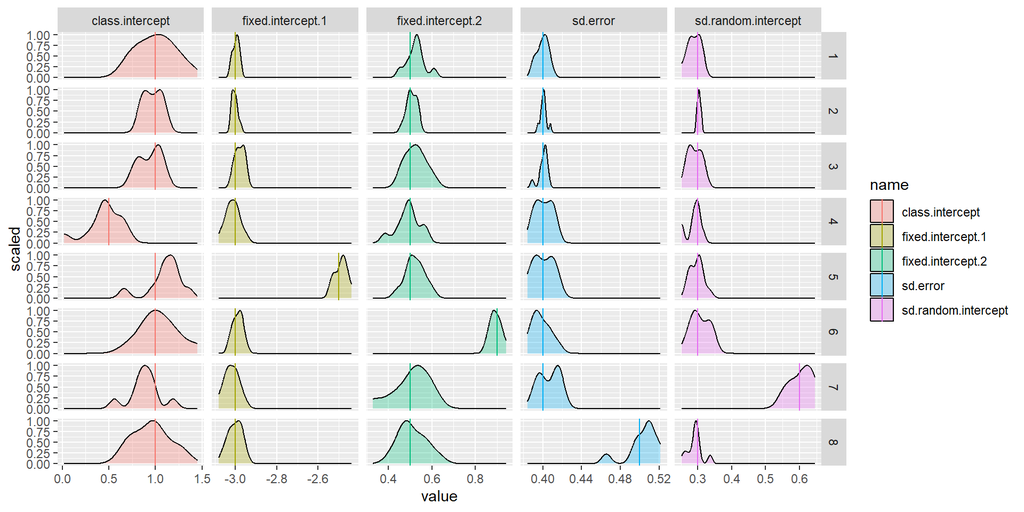

```r
ggplot() +
  geom_density(
    mapping = aes(
      x = value,
      y = after_stat(scaled),
      fill = name
    ),
    data = estimated.parameters %>%
      pivot_longer(
        cols = c("class.intercept", "fixed.intercept.1", "fixed.intercept.2", "sd.random.intercept", "sd.error")
      ),
    alpha = 0.3
  ) +
  geom_vline(
    mapping = aes(
      xintercept = value,
      col = name
    ),
    data = parameters %>%
      pivot_longer(
        cols = c("class.intercept", "fixed.intercept.1", "fixed.intercept.2", "sd.random.intercept", "sd.error")
      )
  ) +
  facet_grid(
    cols = vars(name),
    rows = vars(parameter.set),
    scales = "free"
  )
```

# Visualise Parameter Correlations

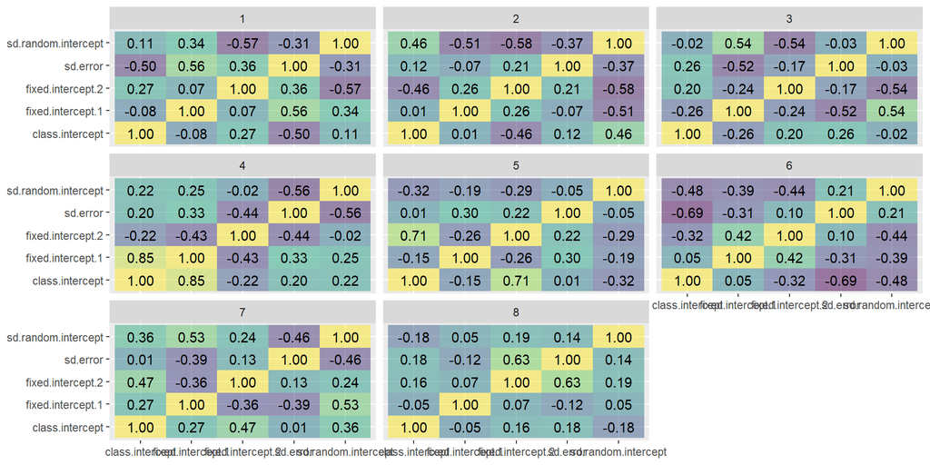

```r
ggplot(
  mapping = aes(
    x = parameter.1,
    y = parameter.2,
    fill = correlation,
    label = sprintf("%.2f", correlation)
  ),
  data = estimated.parameters %>%
    group_by(parameter.set) %>%
    reframe(
      expand_grid(
        parameter.1 = c("class.intercept", "fixed.intercept.1", "fixed.intercept.2", "sd.random.intercept", "sd.error"),
        parameter.2 = c("class.intercept", "fixed.intercept.1", "fixed.intercept.2", "sd.random.intercept", "sd.error")
      ),
      correlation = c(cor(data.frame(class.intercept, fixed.intercept.1, fixed.intercept.2, sd.random.intercept, sd.error)))
    )
) +
  geom_tile(alpha = 0.5) +
  geom_text() +
  scale_fill_viridis_c() +
  guides(fill = "none") +
  labs(
    x = NULL,
    y = NULL
  ) +
  facet_wrap(
    facets = vars(parameter.set)
  )
```

```r
estimated.parameters %>%
  count(
    abs(class.intercept) < 0.01,
    abs(class.intercept_2) < 0.01
  )
```

| abs(class.intercept) < 0.01 | abs(class.intercept_2) < 0.01 | n |
| --- | --- | --- |
| FALSE | FALSE | 80 |

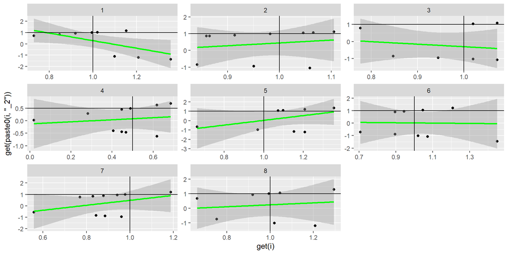

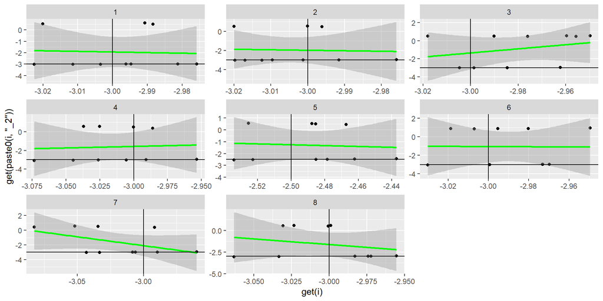

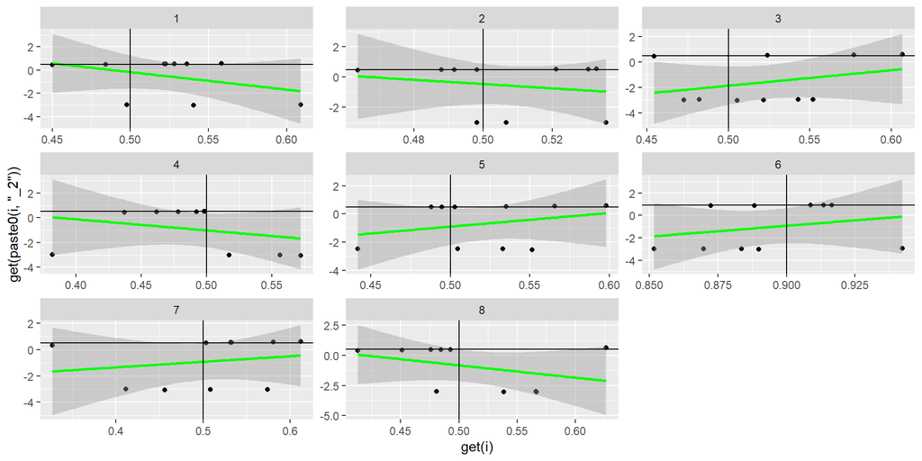

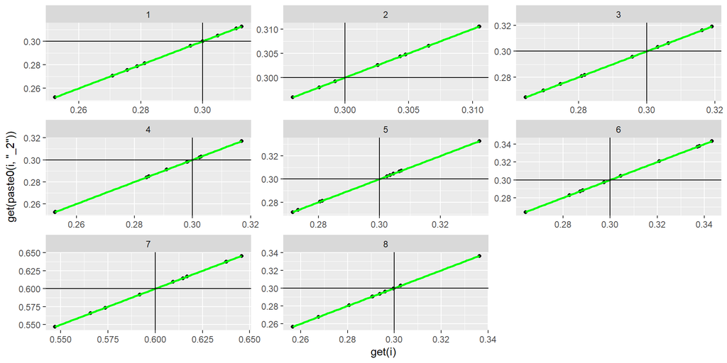

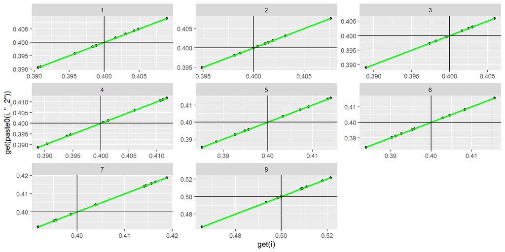

```r
for (i in c("class.intercept", "fixed.intercept.1", "fixed.intercept.2", "sd.random.intercept", "sd.error")) {
  print(
    ggplot(
      mapping = aes(
        x = get(i),
        y = get(paste0(i, "_2"))
      ),
      data = estimated.parameters %>%
        filter(abs(class.intercept_2) > 0.01),
        alpha = 0.1
    ) +
      geom_point() +
      geom_smooth(
        formula = y ~ x,
        method = "lm",
        col = "green"
      ) +
      geom_vline(
        mapping = aes(
          xintercept = get(i)
        ),
        data = parameters
      ) +
      geom_hline(
        mapping = aes(
          yintercept = get(i)
        ),
        data = parameters
      ) +
      facet_wrap(
        facets = vars(parameter.set),
        scales = "free"
      )
  )
}
```